# Exploring the Corona outbreak with R

March 7, 2020

## Overview

- A curiousity timeline
- Some COVID-19 information
- A little R and some visualisations
- Some modelling and estimation

## Timeline

- 22nd Jan: Whatsapp
  - Confirmed cases: 555
- 25th Jan: Whatsapp
  - Confirmed cases: 1,434

[figure not shown]

> John Hopkins Live Tracker Dashboard

## Timeline

- 22nd Jan: Whatsapp
  - Confirmed cases: 555
- 25th Jan: Whatsapp
  - Confirmed cases: 1,434
- 10th Feb: SatRday talk submission
  - Confirmed cases: 42,000

## Timeline

- 22nd Jan: Whatsapp
  - Confirmed cases: 555
- 25th Jan: Whatsapp
  - Confirmed cases: 1,434
- 10th Feb: SatRday talk submission
  - Confirmed cases: 42,000
- 13th Feb: Prof. Vardas @NRF
  - Confirmed cases: 60,429

## COVID-19

\(R_0\): The number of people, on average, that *one sick person* will infect.

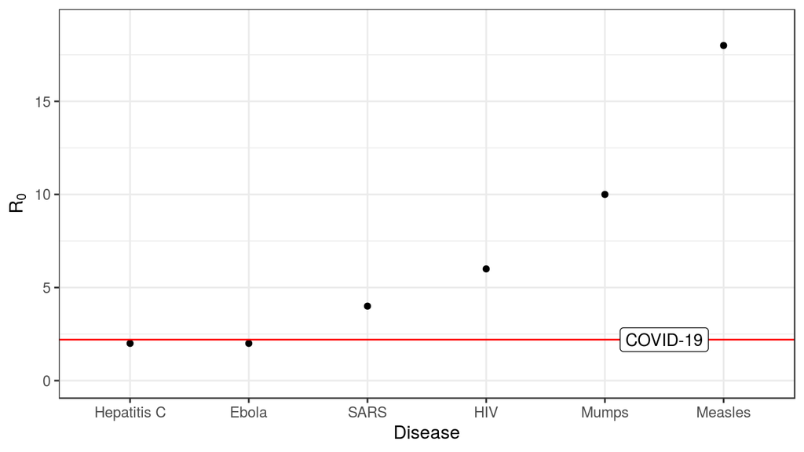

[cboettig gist](https://gist.github.com/cboettig/5600558)

## COVID-19

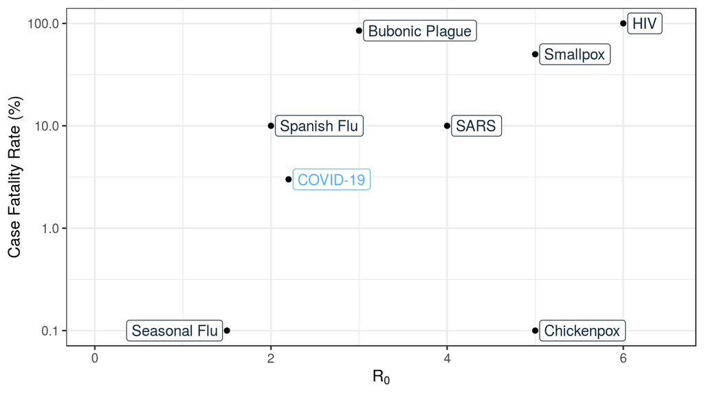

## COVID-19 Origins

[figure not shown]

## COVID-19 Clinical Assessment (T8 -> T11)

[figure not shown]

## Coronaviruses

6 already known to infect humans:

- hCoV-OC63
- hCoV-NL63
- hCoV-HKU1
- hCoV-229E
- SARS-CoV 2002/2003 Guangdong, China
- MERS-CoV 2012 Middle East (ongoing)

## SARS

Easy numbers to remember:

- Outbreak lasted 8 months
- Confirmed cases: 8,000
- Total deaths: 800

## COVID-19

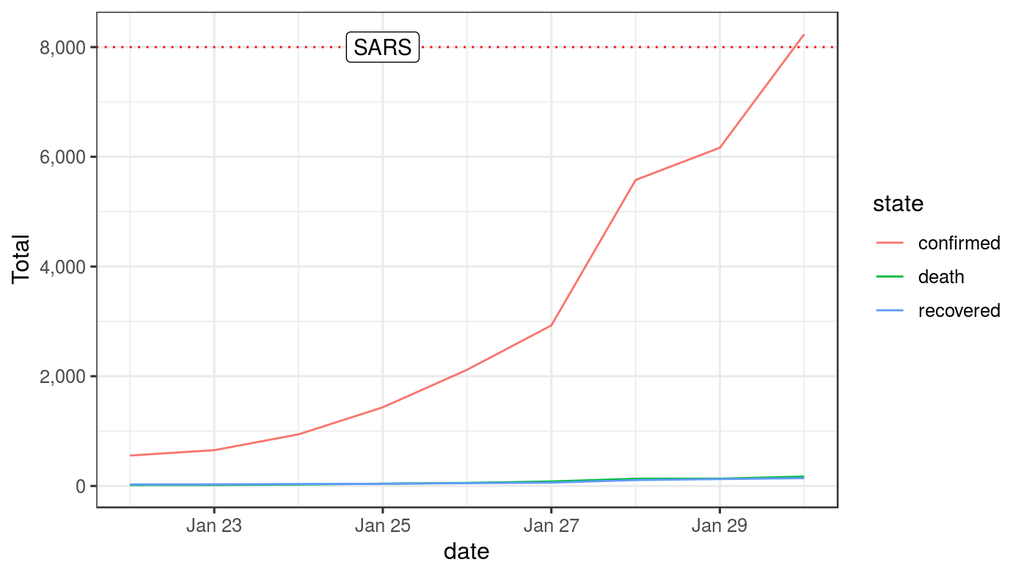

```r
library(scales)
scale_y_continuous(label = comma)
```

## COVID-19 Data

github.com/CSSEGISandData/COVID-19

Tidy-tears

[figure not shown]

## COVID-19 Latest

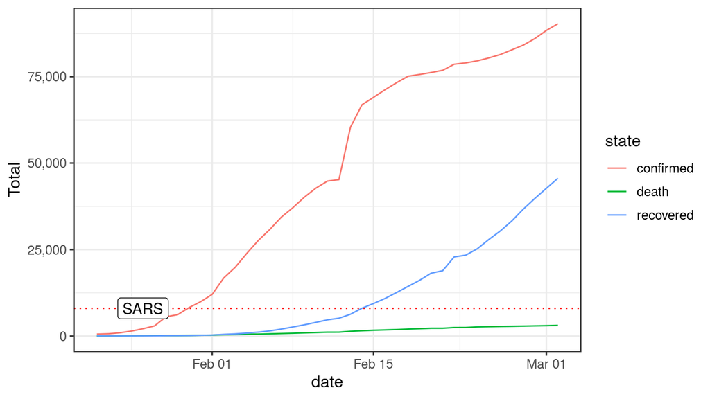

## COVID-19 Latest (Mortality Rates)

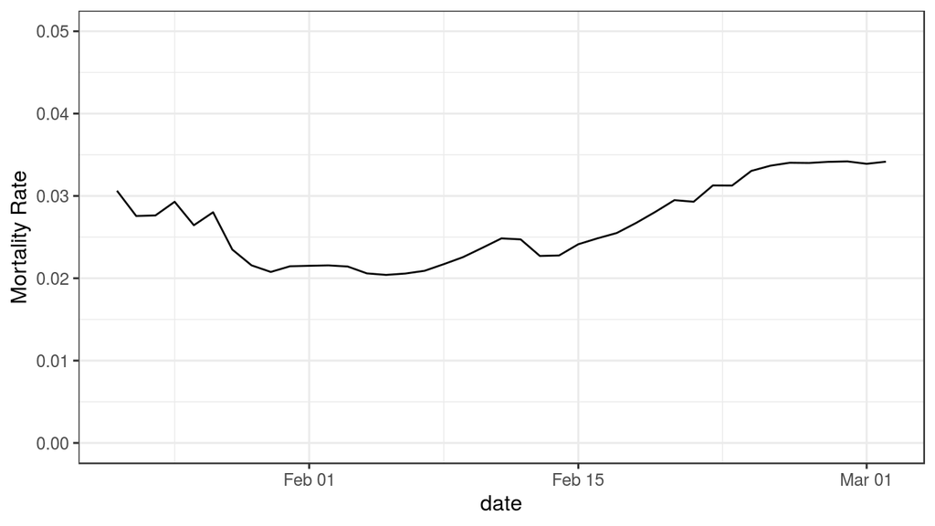

## Mortality Rates (China & !China)

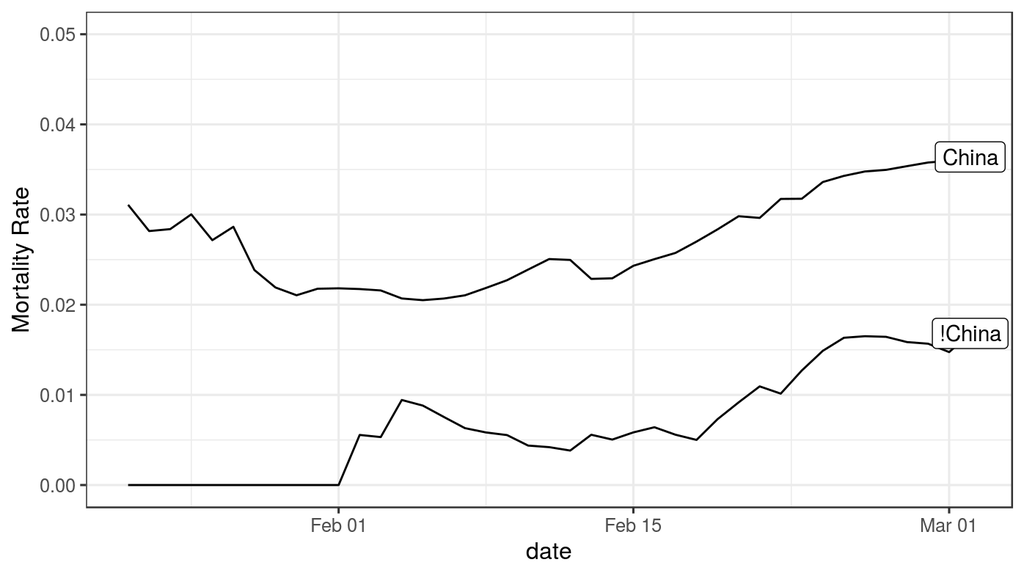

FAIL

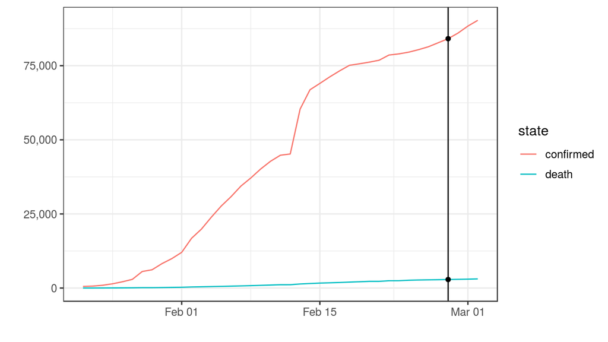

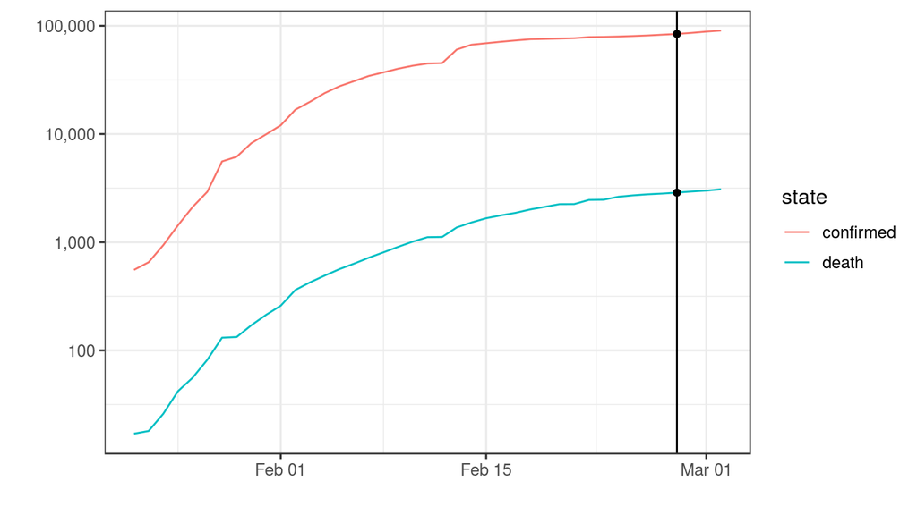

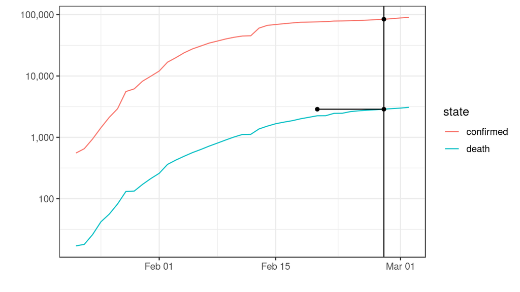

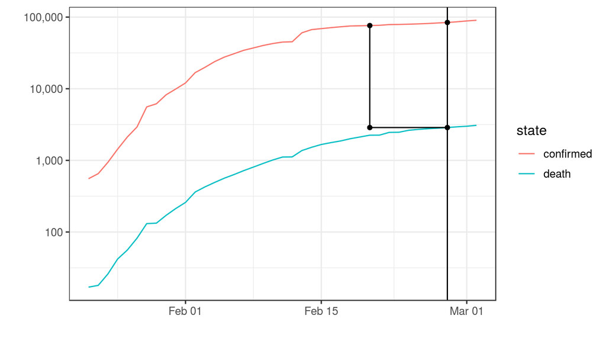

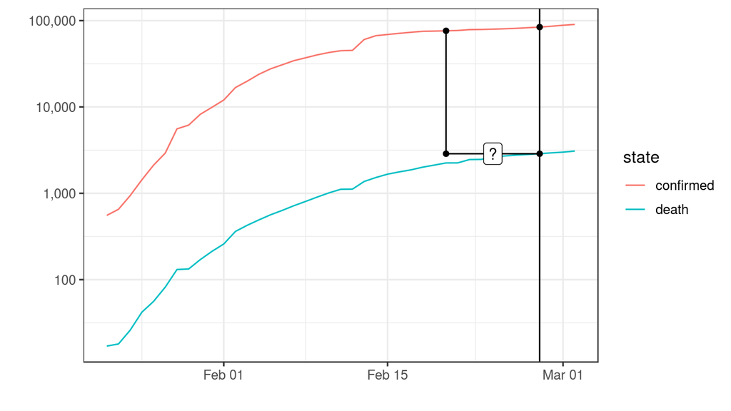

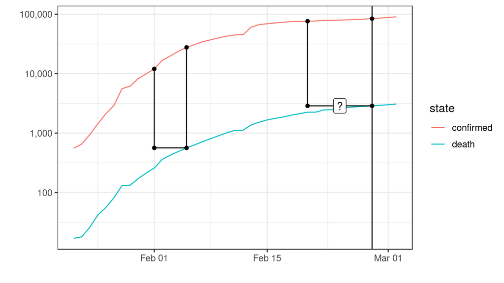

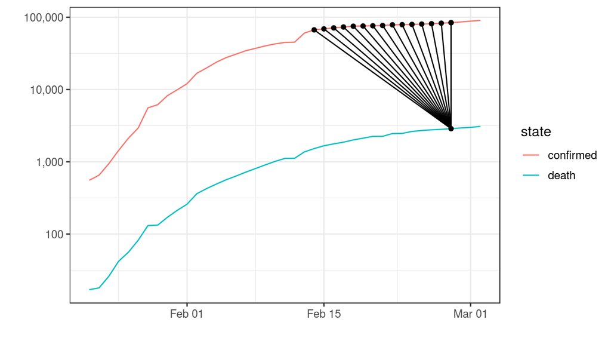

```r
ggplot() + scale_y_log10()
```

## Corrected Mortality Rates (smooth infections)

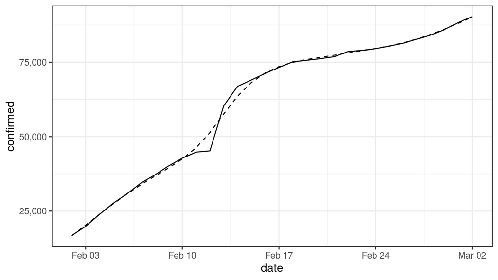

```r
smooth.spline(data$date, data$confirmed, spar = .5)
```

## Corrected Mortality Rates (smooth deaths)

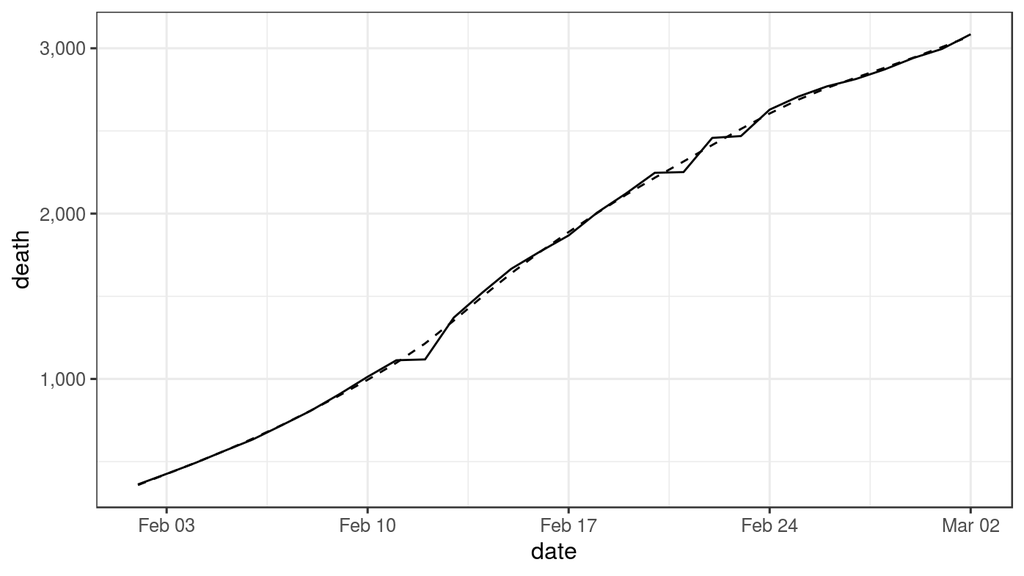

## Corrected Mortality Rates

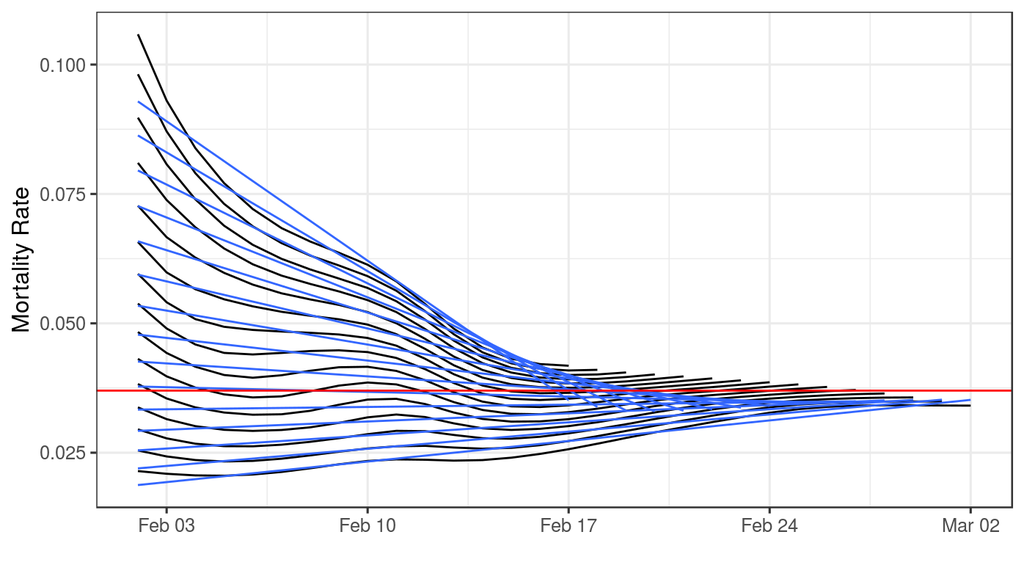

```r
ggplot() + stat_smooth(method = 'lm')
```

## Corrected Mortality Rates

Lag : 5 days from confirmed -> deceased

Mortality rate: 3.7%

## COVID-19 In Mainland China

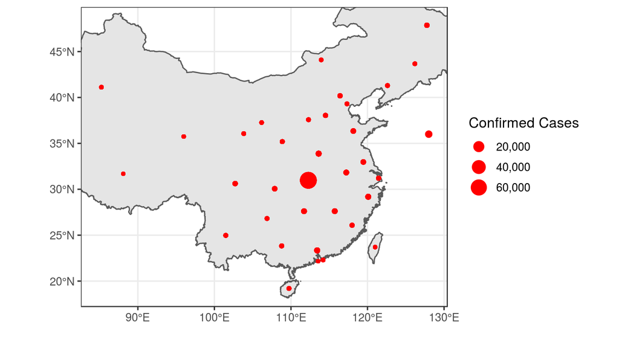

```r
library(sf)
geom_sf(data = china_provinces)
```

[figure not shown]

## Can we do better?

Express the totals on an axis.

Drop the geography. Rather split on countries.

Focus on Top-n elements.

Perhaps scale the totals?

[interactive chart not shown]

## Elsewhere

[interactive chart not shown]

## Outbreak status by local gradient (ggplot)

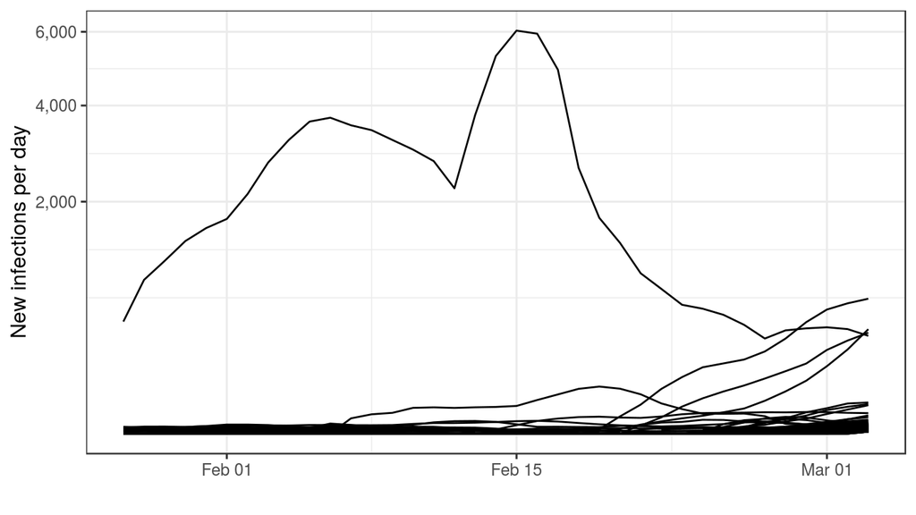

## Outbreak status by local gradient (d3)

[interactive chart not shown]

## Shifting the x-axis to match the outbreak stage

Build a “typical” growth line.

Shift each trajectory by country to “best-fit” existing trends.

## Modelling the typical growth (0:12)

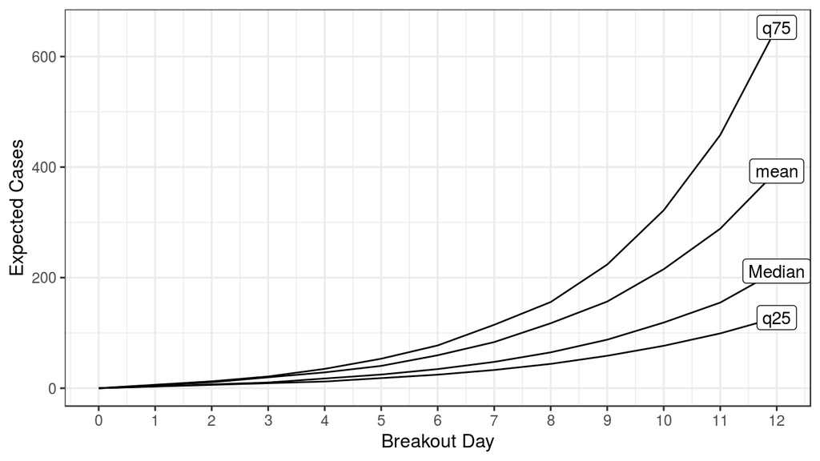

## Modelling the typical growth (0:24)

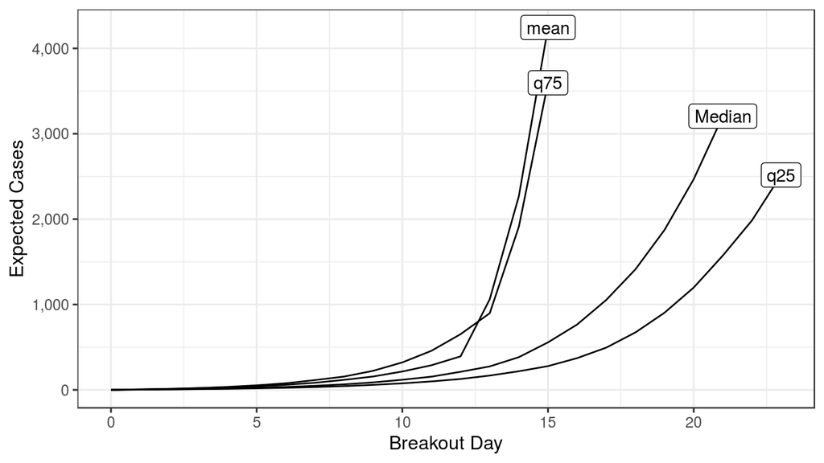

## Putting it together

- Mortality Rates
- Quarantine Policies
- Economic

## R packages

- ioslides : for markdown-based presentations
- tidyr : for data preparation
- dplyr : to target an output format
- ggplot2 : for visualisation
- r2d3 : for better visualisation